# **Predictive Modelling an YELP-Reviews**

## Kann die Nützlichkeit einer YELP-Bewertung von einem Klassifikationsmodell vorhergesagt werden?

#### *Matr.Nr: 1421983*

#### *Datum: 17.08.2018*

[figure not shown]

# 0 Vorwort

Diese Arbeit soll den Prozess zu einem Projektziel (siehe Punkt 1) dokumentieren. In den folgenden Abschnitten werden Textpassagen immer wieder von Code-Teilen unterbrochen. Die Textpassagen enthalten dabei immer die Ideen hinter der Durchführung bestimmter Schritte bzw. wieso diese nötig sind und grob die einzelnen Schritte, die durchgeführt werden. Der Code selbst wird jedoch in den Textpassagen im Regelfall nicht beschrieben, sind der Nachvollziehbarkeit halber so kommentiert, dass der Sinn aller einzelnen Codezeilen auch für nicht-fachkundige nachvollziehbar sein sollte. Diese Kommentare sind dabei in folgender Form geschrieben: `Codezeile #Kommentar zur Funktion der Codezeile`

Zusätzlich werden einige Begriffe gleichwertig in der Dokumentation verwendet, als Beispiele *Review* und *Bewertung*, sowie *User* und *Nutzer*. Weiteres werden der Einfachheit halber die Ursprungs- und auch weiter verarbeiteten Dateien immer als Datenbanken oder Datensets bezeichnet und sollen damit sowohl die Konzepte eines *tibble* (dplyr-Package), eines *data.table*(data.table-Package) und eines *data.frame’s* (base-Package) umfassen und diese nicht auf eine spezielle Form beschränken.

Weiteres wird der Code der Graphiken oder ähnliches erstellt und normalerweiße aus Ästhetikgründen nicht im Outputfile zu sehen ist, da er nur der Visualisierung von Daten dient, hier nur versteckt und kann bei Bedarf ausgeklappt werden - dies soll die komplette Reproduktion der Ergebnisse ermöglichen.

# 1 Einleitung

Durch die Digitalisierung der modernen Welt gibt es schon seit einiger Zeit einen “Ort”, den heutzutage jedes Kind kennt - das Internet. Es umfasst unzählige Mengen an Informationen, die einem den Alltag erleichtern können. Ein Teil davon ist die Webseite [YELP](https://www.yelp.com/). Sie bietet Nutzern auf der ganzen Welt die Möglichkeit, Unternehmen die sie besucht haben, zu bewerten, egal ob es sich dabei um das Restaurant nebenan oder den eigenen Zahnarzt handelt. Ist man nun also auf der Suche nach einem guten, neuen Restaurant gibt es also die Möglichkeit, die Bewertungen anderer Besucher vorher einmal auf YELP einzusehen. Waren diese zufrieden? Wenn nein, wieso nicht, wenn ja wieso? Und ist die von den anderen geschriebene Bewertung für mich oder andere eigentlich nützlich oder gibt sie mir nicht die Informationen die ich brauche?

YELP umgeht dieses Problem, indem sie anderen Nutzern die Möglichkeit geben, Reviews Anderer als nützlich zu bewerten. Eine Frage, die problematisch sein könnte ist jedoch, ob unterschiedliche Nutzer aus unterschiedlichen Gründen ein Review als nützlich bewerten. Werden diese als nützlich bewertet, da sie finden, dass ein Review sehr gut geschrieben ist und gute Pro- und Kontra-Argumente gibt oder weil sie die selben Erfahrungen gemacht haben? Ist ein Review nützlich, weil sie dadurch den Entschluss gefasst haben, das Restaurant auch wirklich zu besuchen oder weil der Verfasser der Bewertung mit ihnen befreundet ist? Natürlich sind diese unterschiedlichen Gründe von Bedeutung, aber eines haben sie gemeinsam - sie hatten mindestens einen Grund (versehentliches anklicken ausgenommen) das Review als nützlich zu bewerten und werden alle Informationen die wir über die Bewertung, das Unternehmen und den Verfasser des Kommentars haben, zusammengetragen, sollte man doch Faktoren finden können, die vorhersagen können, ob ein Review von anderen Nutzern als nützlich bewertet wird.

Dieses Projekt setzt an diesem Punkt an und will genau das explorieren. Die genaue Fragestellung lautet, ob es möglich ist mit Hilfe aus den Ursprungsdaten gewonnener Variablen ein Klassifikationsmodell (auch *Predictive Modelling* oder *Supervised Machine Learning* gennannt) zu erstellen, dass mit einer Wahrscheinlichkeit deutlich über der “No-Information-Rate” (“Rateniveau”) vorhersagen kann, ob andere Nutzer ein Review als nützlich bewerten werden oder nicht?

Natürlich muss eine gewisse Vergleichbarkeit der Reviews vorliegen, da sich die Kriterien der Bewertung eines Bauunternehmens stark von der Bewertung eines Zahnarztes unterscheiden werden. Zusätzlich könnten auch verschiedene Maßstäbe in verschiedenen Ländern als Bewertungsgrundlage herangezogen und somit auch ein Unternehmen, je nach Nationalität, von unterschiedlichen Nutzern unterschiedlich bewertet werden. Die Idee in diesem Projekt ist es also, eine so vergleichbare Menge an Bewertungen wie möglich zu finden, die Unternehmen des selben Landes, bevorzugt auch der selben Stadt, aber trotzdem mit einer ausreichend großen Menge an Bewertungen (die gesamte Datenauswahl soll mehr als 10000 Bewertungen beinhalten) beinhalten soll. Zusätzlich wären Schwankungen der Polarität (Unternehmen als gut vs als schlecht bewertet) bei gleichzeitiger Erhaltung der Vergleichbarkeit von Vorteil.

## 1.1 Die Daten

Zur Durchführung dieses Projektes werden von YELP bereitgestellte Datensets der YELP-Data-Challenge (Version 4), die kostenlos auf kaggle zur Verfügung stehen, verwendet. Diese enthält verschiedene Datensets, die unterschiedliche Informationen zu Unternehmen, Nutzer und Bewertungen enthalten. Die hier für das Projekt verwendeten Daten umfassen die Datensets `yelp_review`, `yelp_user` und `yelp_business`.

*Anmerkung:* Da es mir nicht möglich war, die Dateien reproduzierbar (also nur per Code) von Kaggle als download zur Verfügung zu stellen (es ist ein kostenloser Account zum Herunterladen der Daten erforderlich), muss in den kommenden Codesegmenten darauf hingewiesen werden, dass die Ursprungsdateien per Hand als “.zip-Datei” in den später erstellten Ordner Ursprungsdaten gegeben werden müssen, damit der Code auch wirklich läuft. Alles andere ist automatisiert und die Daten selbst stehen [hier](https://www.kaggle.com/yelp-dataset/yelp-dataset/version/4) kostenlos zum Download zur Verfügung.

Die Struktur der Daten selbst wird unter Punkt 2 näher erläutert.

## 1.2 Gewährleistung einer erfolgreichen Reproduktion der Ergebnisse

Um die Reproduktion der Ergebnisse auch für nicht-fachkundige zu ermöglichen, werden in den folgenden Schritten noch potenzielle Hindernisse erläutert. Sind die Voraussetzungen nicht erfüllt, könnte der Code nicht funktioneren.

### 1.2.1 Die Packages

Die im Anschluss aufgeführten Packages werden automatisch installiert und in R installiert und geladen. DIese sind zur fehlerfreien Reproduktion des nachfolgenden Codes unerlässlich. Treten im Code Fehler auf, liegt das vermutlich daran, dass nicht alle Packages vollständig oder richtig geladen wurden. Fehlerquellen können dabei unterschiedliche Versionen von R, sowie andere Betriebssysteme sein, für welche die Packages nicht ausgelegt wurden.

```r
knitr::opts_chunk$set(echo = TRUE)
if(!require(pacman)) install.packages("pacman")
pacman::p_load(data.table, dtplyr, dplyr, ggplot2, psych, caret, vtreat, randomForest, tm, rlang, qdap, stringi, tictoc, utils, hash, lubridate, parallel, cld2, doParallel, foreach, stats, readability, naivebayes, skimr, e1071, pROC, readr, rpart, reshape2, ggraph, igraph, rattle)

rm(list = ls()) #entfernt alle Elemente aus dem Arbeitsspeicher
```

### 1.2.2 Die Systeminformationen

Eine Reproduktion scheitert häufig daran, dass verschiedene Programmversionen und Betriebssysteme verwendet werden. Für eine Reproduktion ist die Verwendung von Windows 10 und die R-Version 3.4.3 zu empfehlen.

```
##  setting  value
##  version  R version 3.4.3 (2017-11-30)
##  system   x86_64, mingw32
##  ui       RTerm
##  language (EN)
##  collate  German_Austria.1252
##  tz       Europe/Berlin
##  date     2018-08-17
```

```
## Packages -----------------------------------------------------------------
```

```
## [1] package *       version date    source
## <0 rows> (or 0-length row.names)
```

### 1.2.3 Die Speicherung der Daten

Der Ordner `Ursprungsdaten` soll die Datensätze in ihrer Ursprungsform enthalten sein, wohingegen der Ordner `Dateien` zukünftig alle durch den Code erstellten Dateien enthalten soll. Durch regelmäßiges Zwischenspeichern sollen so bereits ausgeführte Schritte nicht wiederholt werden müssen und jeder Codeabschnitt mit speziellen Dateianforderungen führt in seiner Kopfzeile an, welche Datei dafür benötigt wird. Natürlich wird der Code in seiner Form fehlerfrei veröffenticht - sollten also Fehler auftreten, kann dies mit hoher Wahrscheinlichkeit auf unterschiedliche R-Versionen oder ähnlichem zurückgeführt werden.

Für die automatische Ausführung des Codes sollen im Ordner **Ursprungsdaten** die Datensets `yelp_review.csv.zip`, `yelp_user.csv.zip` und `yelp_business.csv.zip` enthalten sein. Sollten Sie diese nicht besitzen, sind diese [hier](https://www.kaggle.com/yelp-dataset/yelp-dataset/version/4) als .zip-Datei downloadbar. Der kommende Codeabschnitt erstellt die relevanten Ordner, und überprüft, ob auch alle Dateien richtig vorhanden sind.

Wenn alle Packages fehlerfrei geladen worden konnten und die Ursprungsdaten sich im dafür vorhergesehenen Ordner befinden, steht der Reproduktion der Daten nichts mehr im Weg.

```r
#setzt das Arbeitsverzeichnis als das Verzeichnis in dem sich diese Datei befindet
x = getwd()
setwd(x)

# erstellt einen Ordner 'Ursprungsdaten' und überprüft, ob alle benötigten Dateien vorhanden sind. Wenn ja, werden diese entpackt. Ist dies nicht der Fall wird darauf hingewiesen, dass die Dateien fehlen und eingefügt werden müssen.
if(!dir.exists("Ursprungsdaten")) {
  dir.create("Ursprungsdaten")
  print("Um die Reproduktion zu ermöglichen, geben Sie bitte die Dateien 'yelp_business.csv', 'yelp_review.csv' und  'yelp_user.csv' in den neu erstellten Ordner 'Ursprungsdaten' - sind diese noch nicht entpackt, werden diese nun entpackt.")
} else if(!("yelp_review.csv" %in% dir(path = paste0(getwd(), "/Ursprungsdaten")) &
     "yelp_user.csv" %in% dir(path = paste0(getwd(), "/Ursprungsdaten")) &
     "yelp_business.csv" %in% dir(path = paste0(getwd(), "/Ursprungsdaten"))) == T) {
    if("yelp_review.csv.zip" %in% dir(path = paste0(getwd(), "/Ursprungsdaten")) &
     "yelp_user.csv.zip" %in% dir(path = paste0(getwd(), "/Ursprungsdaten")) &
     "yelp_business.csv.zip" %in% dir(path = paste0(getwd(), "/Ursprungsdaten")) == T) {
      print("Die benötigten Dateien werden entpackt")
      unzip("Ursprungsdaten/yelp_review.csv.zip", exdir = "Ursprungsdaten")
      unzip("Ursprungsdaten/yelp_user.csv.zip", exdir = "Ursprungsdaten")
      unzip("Ursprungsdaten/yelp_business.csv.zip", exdir = "./Ursprungsdaten")
      print("Alle benötigten Dateien stehen nun zur Verfügung!")
    } else {
      print("Die benötigten Dateien befinden sich noch nicht im Ordner 'Ursprungsdaten' oder sind falsch benannt. Bitte überprüfen Sie ob sich die Dateien als 'yelp_review.csv.zip', 'yelp_user.csv.zip' und 'yelp_business.csv.zip' im Ordner 'Ursprungsdaten befinden. Ist dies nicht der Fall, laden Sie bitte die benötigten Dateien von 'https://www.kaggle.com/yelp-dataset/yelp-dataset/version/4' herunter und geben Sie diese in den Ordner Ursprungsdaten")
    }
} else {
print("Ordern und Dateien vorhanden - let's go!")
}

# erstellt einen Ordner wo zwischengespeicherte Daten gelagert werden
if(!dir.exists("Dateien")) {
  dir.create("Dateien")
  print("Ordner für zwischengespeicherte Daten erstellt - sollte sich der Code aufgrund unvorhergesehener Zwischenfälle aufhängen, kann mit den zwischengespeicherten Daten aus diesem Ordner vom letzten Speicherpunkt wieder  weitergerechnet werden!")
} else {
  print("Ordner für Zwischenspeicherungen bereits vorhanden - sollte sich der Code aufgrund unvorhergesehener Zwischenfälle aufhängen, kann mit den zwischengespeicherten Daten aus diesem Ordner vom letzten Speicherpunkt wieder  weitergerechnet werden!")
}
```

```
## [1] "Ordern und Dateien vorhanden - let's go!"
## [1] "Ordner für Zwischenspeicherungen bereits vorhanden - sollte sich der Code aufgrund unvorhergesehener Zwischenfälle aufhängen, kann mit den zwischengespeicherten Daten aus diesem Ordner vom letzten Speicherpunkt wieder  weitergerechnet werden!"
```

# 2 Projektziel

Das Ziel dieses Projektes ist es, ein Klassifikationsmodell zu erstellen. Ein Klassifikationsmodell soll Anhand eines Trainingsdatensets mit einem vorcodierten Klassifikationsfaktor (hier: nicht nützlich vs nützlich) und einer Menge von Prädiktoren (Metadaten, Variablen, Faktoren, etc.) lernen, wie sich konträre Ausprägungen des Klassifikationsfaktors unterscheiden. Wenn es Unterschiede gibt, ist es dem Modell möglich deutlich über der Ratewahrscheinlichkeit die Daten in die richtige Faktorenstufe einzuteilen - dieser Vorgang nennt sich klassifizieren. (Beispiel: Verteilung 50:50 bei 100 Observationen - Ratewahrscheinlichkeit 50% -> werden alle Daten zufällig eingeteilt, ist die Wahrscheinlichkeit 50%, dass man durch Zufall alles richtig eingeteilt hat). Mit diesem Modell sollen dann auch neue Daten, die genau gleich aufbereitet und noch nicht codiert (also hier von anderen Benutzern als nützlich bewertet) sind, klassifiziert werden können. Ist das Modell gut, funktioniert dies mit ungefähr gleich hoher Genauigkeit auch bei neuen Daten, die dem Modell noch nicht bekannt sind.

Es ist hier also essenziell, Daten aus den Observationen zu gewinnen, die dem Modell helfen sollen, neue Daten richtig zu klassifizieren. Vor der Modellerstellung sollen mit den Observationen folgende 3 Schritte durchgeführt werden:

1. Vergleichbare Unternehmen und somit auch vergleichbare Bewertungen auswählen, damit das Modell nicht nach unterschieden zwischen Äpfel und Birnen sucht (z.B. Vergleich Zahnarztbewertung mit Restaurantbewertung -> unterschiedliche Kriterien -> Modell wird ungenauer)
2. In den Observationen versteckte Informationen müssen extrahiert werden, damit das Modell auch ausreichend Prädiktoren hat, Anhand derer es klassifizieren kann.
3. Aufbereitung der Variablen in eine Form, mit der das Modell arbeiten kann

# 3 Auswahl der Datengrundlage

Interessante Unternehmen sollten vor allem eines sein: Vergleichbar! Da die Datensets von YELP sehr viele unterschiedliche Unternehmenskategorien beinhalten sollen diese auf eine überschaubare, vergleichbare Menge eingegrenzt werden. Eine Unternehmenskategorie die eine gute Vergleichbarkeit mit gleichzeitiger erhaltener Polarität der Reviews gewährleistet, ist die Kategorie Restaurants. Sie besitzen implizite Bewertungsstandards, werden aber trotzdem von Person zu Person unterschiedlich wahrgenommen und somit auch oft zwiegespalten bewertet wird - trotzdem können sie ausreichend in jeder Stadt gefunden werden.

Die Auswahl des Landes fiel dabei auf die USA, da YELP sich vor allem dort großer Beliebtheit erfreut. Um die Auswahl der Restaurants weiter einzuschränken, die USA zusätzlich für Burger bekannt ist und die inoffiziellen Standards von Restaurants wie freundlicher, schneller Service, gutem Essen und einer netten Atmosphäre eine gute Grundlage für vergleichbare Bewertungen legen, wird als erste Grundlage *“Bewertungen (”reviews“) von Restaurants in den USA, die Burger anbieten”* gewählt. Um die weitere Vergleichbarkeit zu erhöhen, sollen die Restaurants auch ähnlich gut bewertet, sowie geographisch im selben Bundesstaat, bevorzugt auch in der selben Stadt liegen. Die genauere Basis wird in unseren Daten exploriert, da eine zu weite Einschränkung der Kriterien die Güte des Modells aufgrund zu geringer Daten beeinflussen könnte.

## 3.1 Exploration der Businessdatenbank und Auswahl der Unternehmen

Zuerst wird die Datenbank `yelp_business`, die Unternehmensinformationen beinhaltet, eingelesen damit sie für die weitere Datenanalyse zur Verfügung steht.

```r
#benötigt yelp_business.csv im Ordner Ursprungsdaten
mysource <- file.path(getwd(), "Ursprungsdaten/yelp_business.csv") #Vektor mit Pfad zur Datei erstellen
business <- fread(mysource, showProgress = F) #einlesen des Businessdatensets
```

Die Datenbank `yelp_business` enthält Informationen über Namen, Adresse und Standort des Unternehmens, die durchschnittliche Bewertungen, Anzahl der Bewertungen und die Kategorien, in die das Unternehmen eingeteilt werden kann.

```r
glimpse(as.tbl(business)) #gibt die Struktur der Datenbank "business" wieder und welche Elemente diese beinhaltet
```

```
## Observations: 174,567
## Variables: 13
## $ business_id  <chr> "FYWN1wneV18bWNgQjJ2GNg", "He-G7vWjzVUysIKrfNbPUQ...
## $ name         <chr> "\"\"Dental by Design\"\"", "\"\"Stephen Szabo Sa...
## $ neighborhood <chr> "", "", "", "", "", "", "Summerlin", "", "", "", ...
## $ address      <chr> "\"\"4855 E Warner Rd, Ste B9\"\"", "\"\"3101 Was...
## $ city         <chr> "Ahwatukee", "McMurray", "Phoenix", "Tempe", "Cuy...
## $ state        <chr> "AZ", "PA", "AZ", "AZ", "OH", "BW", "NV", "NV", "...
## $ postal_code  <chr> "85044", "15317", "85017", "85282", "44221", "705...
## $ latitude     <dbl> 33.33069, 40.29169, 33.52490, 33.38315, 41.11953,...
## $ longitude    <dbl> -111.97860, -80.10490, -112.11531, -111.96473, -8...
## $ stars        <dbl> 4.0, 3.0, 1.5, 3.0, 3.5, 4.0, 4.0, 1.5, 5.0, 5.0,...
## $ review_count <int> 22, 11, 18, 9, 116, 5, 5, 9, 15, 7, 3, 23, 38, 5,...
## $ is_open      <int> 1, 1, 1, 0, 1, 1, 1, 1, 1, 1, 0, 1, 1, 1, 1, 0, 1...
## $ categories   <chr> "Dentists;General Dentistry;Health & Medical;Oral...
```

Ausgewählt werden nur die Spalten, die für die Auswahl der Unternehmen relevant oder für diese Fragestellung einen Informationswert bieten könnten. Diese umfassen die Spalten `business_id`, `city`, `state`, `stars`, `review_count` und `categories`. `categories` ist dabei besonders relevant, da sie es uns erlaubt nach bestimmten Unternehmenskategorien zu filtern. Da R zwischen Groß- und Kleinschreibung unterscheidet wir der enthaltene Text in der Spalte “categories” in Kleinbuchstaben umgewandelt, um auch alle passenden Kategorien im Filterungsprozess zu erhalten.

```r
#auswählen relevanter Kategorien
business <- business %>% select(business_id, city, state, stars, review_count, categories, name)

#Text in Spalte categories in Kleinbuchstaben umwandeln
business$categories = sapply(business$categories, tolower)

gc() #gibt Arbeitsspeicher frei
```

Im nächsten Schritt müssen Unternehmen aus den USA ausgewählt und nach unseren in `2.1` erwähnten Kritieren gefiltert werden.

Um nur Unternehmen aus Amerika zu erhalten, wird die Spalte `state` mit einem Vektor der amerikanischen Bundesstaaten abgeglichen - gibt es keinen Treffer, wird das Unternehmen entfernt.

Nun wird in der Spalte `categories` nach Unternehmen gesucht, die in ihren Kategorien **restaurant** und **burger** enthalten, um vergleichbare Restaurants zu entdecken.

```r
#erstellen einer Kürzelliste der Bundesstaaten von Amerika
states_of_USA = c("AL", "AK", "AZ", "AR", "CA", "CO", "CT", "DE", "FL", "GA", "HI", "ID", "IL", "IN", "IA", "KS", "KY", "LA", "ME", "MD", "MA", "MI", "MN", "MS", "MO", "MT", "NE", "NV", "NH", "NJ", "NM", "NY", "NC", "ND", "OH", "OK", "OR", "PA", "RI", "SC", "SD", "TN", "TX", "UT", "VT", "VA", "WA", "WV", "WI", "WY")

# Filter nach Unternehmen in Amerika und in neues Datenset 'business_USA' geben
business_USA <- business %>% filter(ifelse(business$state %in% states_of_USA, TRUE, FALSE) == T)

# Filter nach allen Unternehmen, die Restaurants sind und Burger verkaufen
restaurant_USA <- business_USA %>% filter(grepl("restaurant", categories) == T &
                                          grepl("burger", categories) == T)

#Entfernen der unnütz gewordenen Datenbanken um Speicherplatz freizugeben
rm(business, business_USA)
gc()
```

Wie eine kurze Zusammenfassung folgende Zusammenfassung zeigt, konnten 3196 auf YELP bewertete, sich in den USA befindliche Burgerrestaurants identifiziert werden.

Die Graphik visualisiert diese Verteilung und zeigt die Bundesstaaten von den USA mit der jeweiligen Anzahl an Burgerrestaurants. Die Bundesstädte mit den meisten Burgerrestaurants sind dabei in absteigenden Grüntönen schattiert. Diese sind **Arizona** (AZ) mit 1030, *Nevada* (NV) mit 652 und *Ohio* (OH) mit 574 individuellen Restaurants.

```r
#Zusammenfassung
restaurant_USA %>% summarise("Anzahl von Burgerrestaurants in den USA" = n())
```

```
##    Anzahl von Burgerrestaurants in den USA
## 1:                                    3196
```

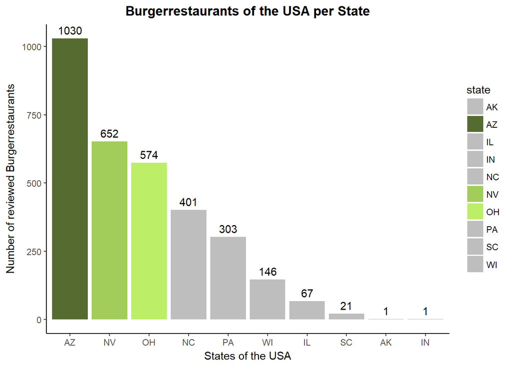

```r
#Funktion die in Diagrammen zur Darstellung der einzelnen Werte verwendet wird
n_fun <- function(x){
  return(data.frame(y = mean(x), label = x))
}

#Graph, der die Verteilung der Burgerrestaurants in den USA visualisieren soll
x = restaurant_USA %>% group_by(state) %>% summarise(n_states = n()) %>% arrange(desc(n_states))
ggplot(data = x, aes(x = reorder(state, -n_states), y = n_states, fill = state)) +
  geom_bar(stat = "identity") + #erstellt ein Balkendiagramm
  theme_classic() + #im klassischen Stil
  #färbt Balken ein
  scale_fill_manual(values=c("grey", "darkolivegreen", "grey", "grey", "grey", "darkolivegreen3", "darkolivegreen2", "grey", "grey", "grey", "grey")) +
  ggtitle("Burgerrestaurants of the USA per State") + #Titel des Plots
  theme(plot.title = element_text(face = "bold", hjust = 0.5)) + #Titel soll fett und zentriert sein
  xlab("States of the USA") + #X-Achsen-Beschriftung
  ylab("Number of reviewed Burgerrestaurants") + #Y-Achsen-Beschriftung
  stat_summary(fun.data = n_fun, geom = "text", vjust = -.5) #gibt Werte der einzelnen Balken zurück
```

Da Arizona die meisten bewerteten Restaurants besitzt, wird im nächsten Schritt nach der Stadt in Arizona gesucht, die die höchste Anzahl an Bewertungen enthält. Die nächste Graphik zeigt die Städte von Arizona mit den meisten Restaurantbewertungen, wobei **Phoenix** mit 34033 alle anderen Städte Arizonas weit abschlägt und somit in der weiteren Analyse verwendet wird.

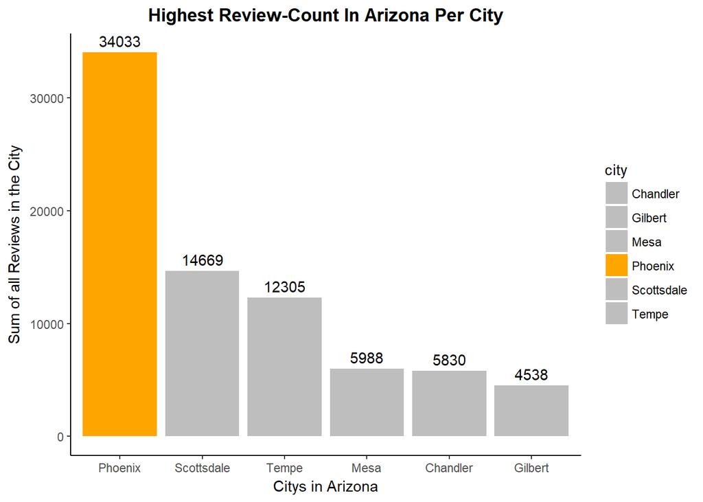

```r
restaurants_AZ <- restaurant_USA %>% filter(state == "AZ") #nur Burgerrestaurants in Arizona

#nur die ersten 6 Städte mit den meisten Reviews in Arizona anzeigen
x = head(restaurants_AZ %>% group_by(city) %>% summarise(reviews_per_city = sum(review_count)) %>% arrange(desc(reviews_per_city)))

#Visualisieren der gefilterten Städte
ggplot(data = x, aes(x = reorder(city, -reviews_per_city), y = reviews_per_city, fill = city)) +
  geom_bar(stat = "identity") +
  theme_classic() +
  scale_fill_manual(values=c("grey", "grey", "grey","orange1", "grey", "grey")) +
  ggtitle("Highest Review-Count In Arizona Per City") +
  theme(plot.title = element_text(face = "bold", hjust = 0.5)) +
  xlab("Citys in Arizona") +
  ylab("Sum of all Reviews in the City") +
  stat_summary(fun.data = n_fun, geom = "text", vjust = -.5)
```

```r
#filtert nur Restaurants in Phoenix aus dem Datenset
restaurants_phoenix = restaurants_AZ %>% filter(city == "Phoenix")

#zählt Anzahl der Restaurants in Phoenix
restaurants_phoenix %>% summarise(restaurants_in_phoenix = n())
```

```
##    restaurants_in_phoenix
## 1:                    367
```

Nach der Auswahl von Phoenix bleiben, wie die folgende Zusammenfassung zeigt, immer noch 367 Restaurants übrig, die, wie vorher exploriert insgesamt 34033 mal bewertet wurden. Da die Anzahl der Bewertungen immer noch sehr groß ist, wird im nächsten Schritt versucht die Vergleichbarkeit der Bewertungen noch weiter zu erhöhen.

In diesem Schritt wurde die Restaurantauswahl somit nur noch Burgerrestaurants beschränkt, die eine Gesamtbewertung von mindestens 4 Sternen, also eine durchschnittlich sehr positive Bewertung, aufweisen und die oft genug bewertet wurden. Gut bewertete Restaurants mit geringer Review-Anzahl könnten eventuell unter- oder überbewertet sein und diese Restaurants somit auch die Vergleichbarkeit einschränken. Um dieses Problem gar nicht erst aufkommen zu lassen, wurde zusätzlich die Mindestreviewzahl auf 100 beschränkt.

```r
# Unternehmen mit > 4 Sternen, die bereits häufig bewertet wurden (mehr als 99 Reviews) + in der gleichen Stadt (Phoenix) liegen um eine homogene Stichprobe zu erhalten und Vergleichbarkeit zu gewährleisten
restaurants_phoenix = restaurants_phoenix %>% filter(review_count >= 100 & stars >= 4)

save(restaurants_phoenix, file = "Dateien/restaurants_phoenix.RData") #speichern des neuen Sets
```

Die übrig gebliebene Datenbank umfasst nun also *55 Burgerrestaurants aus Phoenix mit einer mindestens 4 Sterne-Bewertung und mindestens 100 Reviews* (alle 5-Sterne Restaurants hatten weniger als 100 Reviews, womit die Stichprobe nur mehr 4 & 4.5-Sterne Bewertungen enthält). Die Vergleichbarkeit der Unternehmen sollte nun also gewährleistet sein.

In einem letzten Schritt werden hier noch diese 55 Restaurants Anhand ihrer gesamten Reviewanzahl, gruppiert nach Sterne-Bewertung zur besseren Visualisierung der übrig gebliebenen Datenmenge, dargestellt.

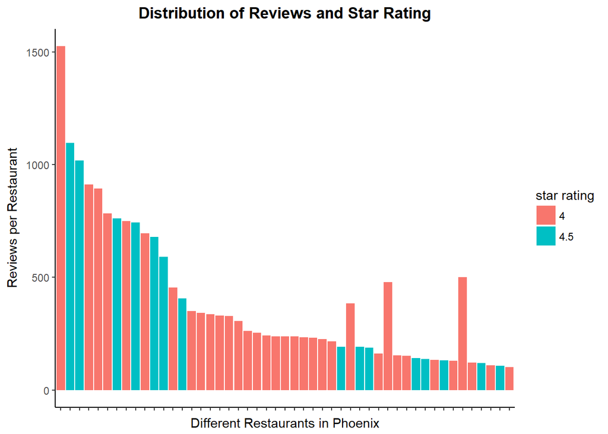

```r
# Verteilung der Reviews über die Kategorien
ggplot(restaurants_phoenix, aes(x = reorder(name, -review_count), y = review_count, fill = as.factor(stars))) +
  geom_bar(stat = "identity") +
  theme_classic() +
  #keine automatische Beschriftung der X-Achse, da sonst nichts mehr lesbar ist
  theme(axis.text.x=element_blank()) +
  ggtitle("Distribution of Reviews and Star Rating") +
  theme(plot.title = element_text(face = "bold", hjust = 0.5)) +
  xlab("Different Restaurants in Phoenix") +
  ylab("Reviews per Restaurant") +
  #füllt unterschiedliche Kategorien unterschiedlich
  scale_fill_discrete(name = "star rating")
```

## 3.2 Angleichen der Review- an die neue Businessdatenbank

Da das Businessdatenset nun nicht mehr alle Daten enthält, enthält unser aktuelles Review-Datenset natürlich noch etliche Reviews, die nicht unsere Restaurants in Phoenix betreffen. Angeglichen werden die Datenbanken durch eine ID-Spalte, die es erlaubt nach Übereinstimmung zu suchen und nur Daten zurückzugeben, wo die ID-Variable in beiden Datensets zu finden war.

Die Datenbank `yelp_review` umfasst ID-Variablen (review, business & user-ID), Sternebewertung, Datum des Reviews, Review selbst (“text”) sowie die Anzahl der Bewertungen eines Reviews als *useful*, *funny* und/oder *cool*.

Eine Auswahl bestimmter Variablen wird vorerst noch unterlassen, da im Moment noch alle Daten ihren Nutzen haben könnten und zuerst weiterverarbeitet bzw. aufbereitet werden müssen.

```r
#benötigt yelp_review.csv im Ordner Ursprungsdaten + restaurants_phoenix

#Laden der Review-Datenbank
mysource2 <- file.path(getwd(), "Ursprungsdaten/yelp_review.csv")
reviews = read.csv(mysource2) #fread konnte die Textdaten nicht richtig einlesen, deshalb read.csv


#Angleichen der Reviews an die richtigen Unternehmen + speichern
reviews = as.data.table(reviews)
reviews_phoenix = semi_join(reviews, restaurants_phoenix, by = "business_id")
save(reviews_phoenix, file = "Dateien/reviews_phoenix.RData")

rm(reviews) #Entfernen der unnütz gewordenen Riesendatenbank "reviews"
gc()
```

```
##             used   (Mb) gc trigger   (Mb)  max used   (Mb)
## Ncells  14940144  797.9   25102783 1340.7  14967266  799.4
## Vcells 457433386 3490.0  656605385 5009.6 654404329 4992.8
```

```r
#Darstellen der Struktur des neuen review-files
glimpse(as.tbl(reviews_phoenix))
```

```
## Observations: 19,349
## Variables: 9
## $ review_id   <fct> hLnwOqChqZwKf8xCZTGkTg, LG8qwf2aJvg4EgQT-y4GPg, Q0...
## $ user_id     <fct> _EU5MxIQ_nmdnnLoJSCvUw, tTnSnlNMWc5GILdvLgih7A, hN...
## $ business_id <fct> -ZBfr1BHvArFp1d6XH8jOQ, -ZBfr1BHvArFp1d6XH8jOQ, -Z...
## $ stars       <int> 5, 5, 5, 5, 5, 4, 2, 4, 3, 5, 5, 4, 1, 5, 4, 5, 5,...
## $ date        <fct> 2015-05-13, 2014-12-28, 2014-10-19, 2017-05-08, 20...
## $ text        <fct> I write this review as my boyfriend is next to me ...
## $ useful      <int> 3, 0, 0, 0, 0, 1, 0, 0, 0, 0, 0, 1, 0, 1, 0, 0, 1,...
## $ funny       <int> 0, 0, 0, 0, 0, 0, 0, 0, 0, 0, 0, 1, 0, 0, 0, 0, 0,...
## $ cool        <int> 1, 0, 0, 0, 0, 1, 0, 0, 0, 0, 0, 1, 0, 0, 0, 0, 1,...
```

## 3.3 Angleichen der User- an die neue Reviewdatenbank

Auch das Userdatenset ist nicht mehr aktuell, nur das dieses mit den Businessdaten keine ID-Variable teilt. Als Vergleichsgrundlage zur Anpassung an die aktuellen Daten wird jedoch das Review-Datenset verwendet und somit nur Userdaten behalten, die ein Review bei einem der ausgewählten Restaurants in Phoenix hinterlassen haben (da das Review-Set schon angeglichen wurde).

Das `yelp_user`-Set umfasst: die “user_id”, den Namen des Users, Anzahl der geschriebenen Reviews (“review_count”), seit wann YELP verwendet wird (“yelping_since”), Freunde des Nutzers (“friends”), Anzahl von anderen Nutzer als “useful”, “funny” und “cool” bewertetete Kommentare, die Anzahl der Jahre, die ein User Elite-Status hatte (“elite”), die durchschnittlich vergebene Anzahl an Sternen bei den Bewertungen (“average_stars”) und 11 verschiedene Arten von Komplimenten, die an den User vergeben wurden.

```r
#benötigt yelp_user.csv im Ordner Ursprungsdaten + reviews_phoenix

#Laden der Userdatenbank
mysource3 <- file.path(getwd(), "Ursprungsdaten/yelp_user.csv")
users <- fread(mysource3, showProgress = F)

#Angleichen der User-Datenbank an die richtigen Reviews + speichern
users = as.data.table(users)
users_phoenix = semi_join(users, reviews_phoenix, by = "user_id")
save(users_phoenix, file = "Dateien/users_phoenix.RData")

# Darstellung der Struktur des neuen user-Files
glimpse(as.tbl(users_phoenix))
```

```
## Observations: 14,755
## Variables: 22
## $ user_id            <chr> "--4rAAfZnEIAKJE80aIiYg", "--Nnm_506G_p8MxA...
## $ name               <chr> "Mesut", "Shauna", "Ryan", "Monique", "Lynn...
## $ review_count       <chr> "28", "20", "102", "11", "399", "6", "5", "...
## $ yelping_since      <chr> "2013-09-14", "2013-02-23", "2014-11-03", "...
## $ friends            <chr> "None", "GP8Q8CNFEHC-Fkra1Smf5A, ApZMnmtLhi...
## $ useful             <chr> "12", "1", "44", "9", "820", "0", "0", "9",...
## $ funny              <chr> "5", "0", "13", "2", "797", "0", "0", "2", ...
## $ cool               <chr> "1", "0", "12", "1", "830", "0", "0", "1", ...
## $ fans               <chr> "0", "1", "1", "0", "42", "0", "1", "1", "1...
## $ elite              <chr> "None", "None", "None", "None", "2010, 2012...
## $ average_stars      <chr> "2.45", "2.76", "4.47", "4.08", "4.12", "3....
## $ compliment_hot     <chr> "0", "0", "1", "0", "532", "0", "0", "0", "...
## $ compliment_more    <chr> "0", "0", "0", "0", "32", "0", "0", "0", "3...
## $ compliment_profile <chr> "0", "0", "0", "0", "9", "0", "0", "0", "47...
## $ compliment_cute    <chr> "0", "0", "0", "0", "20", "0", "0", "0", "9...
## $ compliment_list    <chr> "0", "0", "0", "0", "14", "0", "0", "0", "2...
## $ compliment_note    <chr> "3", "0", "0", "0", "224", "0", "0", "1", "...
## $ compliment_plain   <chr> "1", "1", "3", "0", "425", "0", "0", "0", "...
## $ compliment_cool    <chr> "0", "0", "2", "0", "696", "0", "1", "0", "...
## $ compliment_funny   <chr> "0", "0", "2", "0", "696", "0", "1", "0", "...
## $ compliment_writer  <chr> "0", "0", "0", "0", "92", "0", "0", "0", "2...
## $ compliment_photos  <chr> "0", "0", "1", "0", "1", "0", "0", "0", "10...
```

```r
#Entfernen der unnütz gewordenen Riesendatenbank "users"
rm(users)
gc()
```

```
##             used   (Mb) gc trigger   (Mb)  max used   (Mb)
## Ncells  14957625  798.9   25102783 1340.7  16016132  855.4
## Vcells 460849799 3516.1  789016433 6019.8 708139294 5402.7
```

Eine kleine Zusammenfassung zeigt uns, dass nach den ersten Schritten *55 Restaurants*, *14755 Nutzer* und *19349 Bewertungen* übrig geblieben sind, was zeigt, dass einige Nutzer für mehr als nur eines der Restaurants ein Review verfasst haben. Ein User hat sogar 31 der Restaurants bewertet, weshalb zumindest minimale Abhängigkeiten entstehen könnten. Dies wird jedoch nicht bereinigt, da auch in der Realität viele Nutzer mehrere Kommentare schreiben können und Abhängigkeiten so nicht unwahrscheinlich sind.

```r
#Anzahl der übrig gebliebenen Restaurants, Nutzer und Reviews
reviews_phoenix %>% summarise(number_of_restaurants = n_distinct(business_id),
                                number_of_different_users = n_distinct(user_id),
                                number_of_reviews = n_distinct(review_id))

#Anzahl der Restaurants, bei denen die User Bewertungen verfasst haben (geordnet nach Häufigkeit)
head(reviews_phoenix %>% group_by(user_id) %>% summarise(max_reviews_user = max(n())) %>% arrange(desc(max_reviews_user)))
```

```
## Source: local data table [1 x 3]
##
## # A tibble: 1 x 3
##   number_of_restaurants number_of_different_users number_of_reviews
##                   <int>                     <int>             <int>
## 1                    55                     14755             19349
## Source: local data table [6 x 2]
##
## # A tibble: 6 x 2
##   user_id                max_reviews_user
##   <fct>                             <int>
## 1 d_TBs6J3twMy9GChqUEXkg               31
## 2 WMMI5Q4Rmm1Rqdu0jOvyhQ               23
## 3 cMEtAiW60I5wE_vLfTxoJQ               19
## 4 dEk7mXM4npuDPmxrwPcEgQ               18
## 5 SRK_sUnvRmMwfexoL_DLQA               15
## 6 6jz_Yr6_AP2WWLbj9gGDpA               15
```

# 4 Extrahieren in den Daten versteckter Informationen

In diesem Schritt ist das Ziel, Informationen aus den Daten zu gewinnen, die die spätere Klassifikation und Modellbildung hoffentlich ausschlaggebend beeinflussen und eine Klassifikation ermöglichen.

Da vor allem die Reviews selbst in ihrer derzeitigen Form nicht viel Informationswert bieten, besteht die nächste Herausforderung daraus, Kennwerte aus den bestehenden Daten zu gewinnen. Eine naheliegende Idee ist, die Länge des Reviews zu betrachten und zu hoffen, dass längere Reviews nützlicher sind. Jedoch muss auch angemerkt werden, dass Reviews auch kurz und prägnant sein können. Was man als besser erachtet, dürfte sehr subjektiv sein bzw. davon abhängen, welche Konsequenzen eine schlechte Entscheidung mit sich bringen könnte. Es ist also wie in `2 Projektziel` bereits angesprochen wichtig genügend Variablen zu haben, die im besten Fall unnütze von nützlichen Kommentaren unterscheiden.

## 4.1 Der flesch-kincaid grade level & reading ease Index

Der erste Wert, der aus den Daten gewonnen werden kann ist die die Komplexität des Textes. Ein Konzept, welches darüber hoffentlich Aufschluss geben wird, ist der `flesch-kincaid-grade-level`-Index & `flesch-kincaid-reading ease`-Index.

Der **reading-ease-Wert** beschreibt, wie schwer Texte zu lesen sind und orientiert sich dabei an Merkmalen wie Satzlänge Wortanzahl und Silbenanzahl. Je höher der erzielte Wert ist, desto leichter ist der Text zu lesen. Ein 12-Jähriger erzielt dabei im Durchschnitt einen Wert zwischen 60 & 70 und Harvard-Paper einen Wert um ungefähr 30. Es werden dabei die Silben, die Wortanzahl und die Anzahl der Sätze speziell gewichtet und miteinander verrechnet. Der entstehende Wert kann Anhand folgender Tabelle (entnommen aus Wikipedia) interpretiert werden:

| Reading-ease-Wert | Wie einfach ist der Text zu lesen? |
| --- | --- |
| 100.00-90.00 | Sehr einfach zu lesen. Auch schon leicht vom durchschnittlichen Elfjährigen verstanden. |
| 90.0-80.0 | Leicht zu lesen. Normale Kommunikationssprache. |
| 80.0-70.0 | Einigermaßen leicht zu lesen. |
| 70.0-60.0 | Normale Sprache. Leicht für den durchschnittlichen 13-Jährigen zu lesen |
| 60.0-50.0 | Einigermaßen schwer zu lesen. |
| 50.0-30.0 | Schwer zu lesen. |
| 30.0-0.0 | Sehr scher zu lesen - wird hauptsächlich von Universitätsabsolventen verstanden. |

Im Gegensatz dazu steht der **flesch-kincaid grade level**, der sich zwar an den gleichen Werten orientiert, diese aber anders gewichtet und somit keine direkte Umrechnung der beiden Werte möglich ist. Der Wert soll aussagen, wie viele Schuljahre eine Person absolviert haben muss, um den Text zu verstehen. Dieser ist jedoch auf das amerikanische Schulsystem, sowie die englische Sprache geeicht und nicht auf andere Sprachen übertragbar (da z.B. vor allem im Deutschen Wörter oft viele Silben haben und den Wert verfälschen).

Für mehr Informationen ist der Wikipedia-Artikel [hier](https://en.wikipedia.org/wiki/Flesch%E2%80%93Kincaid_readability_tests) zu finden.

### 4.1.1 Die adaptierte Flesch-Kincaid-Funktion

In den folgenden Codeblöcken können die Funktionen durch ausklappen genauer betrachtet werden - diese enthalten selbst erstellte Hilfsfunktionen und eine adaptierte Funktion der flesch_kincaid-Version von qdap. Die adaptierte Version ist im Gegensatz zur Originalfunktion in diesem Versuch deutlich effizienter und Arbeitsspeicher sparender, dafür aber deutlich rigider in ihrer Anwendbarkeit, da Elemente, wie z.B. die Gruppierungsmöglichkeit entfernt und andere, hier wichtige Elemente beigefügt wurden.

Die größten Unterschiede der adaptierten flesch-kincaid-Version sind, dass:

1. nur die für dieses Projekt relevanten Kennwerte (FK-grade-level & reading ease + Wörteranzahl) wirklich zurückgegeben werden
2. diese direkt als Vektor ans Datenset angehängt und nicht viele unnütze Kennwerte als List of Lists zurückgegeben werden. Für nähere Informationen ist die Originalfunktion unter `getAnywhere(flesch_kincaid)` zu finden und der gesamte folgende Codeblock in seinen Schritten kommentiert.

```r
#eine modifizierte Version der Original flesch_kincaid-Funktion von qdap (siehe getAnywhere(flesch_kincaid)), die schonender für den Arbeitsspeicher ist, da sie nicht so viele unnütze Werte speichert
mutated_flesch_kincaid = function (data_frame, text.var, env = namespace:qdap) {
  #text-Variable wird in Charakter umgewandelt
  text = as.character(text.var)
  #Arbeitsdatenset wird mit der Textvariable erstellt
  DF <- data.frame(text.var = text, stringsAsFactors = FALSE)
  #zählt die Wortanzahl eines Reviews
  DF$word.count_before_pp <- word_count(DF$text.var)
  #zählt die Gesamtanzahl der Silben eines Reviews
  DF$syllable.count <- syllable_sum(DF$text.var)
  #zählt die Gesamtanzahl der Sätze eines Reviews
  DF = n_sentences_full(data_frame = DF, text.var = DF$text.var)
  #flesch-kincaid-grade-level Funktion
  fkgl <- function(tw, tse, tsy){ 0.39 * (tw/tse) + 11.8 * (tsy/tw) - 15.59}
  #flesch-kincaid-reading-ease Funktion
  fre <- function(tw, tse, tsy){ 206.835 - 1.015 * (tw/tse) - 84.6 * (tsy/tw)}
  #Anwenden der Funktion fkgl und hinzufügen der erhaltenen Werte zum Ursprungsdatenset
  data_frame$FK_grade_level <- with(DF, fkgl(tw = word.count_before_pp, tse = n_sentences, tsy = syllable.count))
  #Anwenden der Funktion fre und hinzufügen der erhaltenen Werte zum Ursprungsdatenset
  data_frame$FK_reading_ease <- with(DF, fre(tw = word.count_before_pp, tse = n_sentences, tsy = syllable.count))
  #Hinzufügen der Wörteranzahl, die später auch noch benötigt wird
  data_frame$word_count_b_pp = DF$word.count_before_pp
  return(data_frame) #Rückgabe des modifizierten Datensets
}

gc()
```

```
##             used   (Mb) gc trigger   (Mb)  max used   (Mb)
## Ncells  14977323  799.9   25102783 1340.7  17799572  950.6
## Vcells 460881639 3516.3  789016433 6019.8 708139294 5402.7
```

### 4.1.2 Hilfsfunktion `clean_data`

```r
load("Dateien/reviews_phoenix.RData") #laden der aktuellsten Datei

#kleine Hilfsfunktion, um Daten für die "mutated_flesch_kincaid"-Funktion aufzubereiten
clean_data <- function(data_frame, text.var) {
  # Text in Charakter umwandeln
  text = as.character(text.var)
  # nicht-Buchstaben des lateinischen Alphabets entfernen (Buchstaben wie "à" töten die "mutated_flesch_kincaid"-Funktion, die unten folgt)
  text = iconv(text, "latin1", "ASCII", sub="")
  #die bereinigte Textvariable ist die neue Textvariable
  data_frame$text = text
  return(data_frame)
}
```

### 4.1.3 Hilfsfunktion `n_sentences`

```r
#kleine Hilfsfunktionfür die flesch-kincaid-Formel, die Satzanzahl zurückgibt, da qdap::sentSplit() nicht effizient auf eine große Datenmenge anwendbar ist
n_sentences_full = function(data_frame, text.var) {
  #Kopie des Eingabe-Datenset wird erstellt
  DF <- data_frame
  #Satzendezeichen werden definiert
  endmarks = c("?", ".", "!", "|")
  #ein Muster der Satzendzeichen wird erstellt, die die "gregexpr"-Funktion verwenden kann
  splitpoint <- paste0("[", paste("\\", endmarks, sep = "", collapse = ""), "]")
  input = text.var #die Textvariable des Inputs wird als "input" gespeichert
  #in den einzelnen Textvariablen wird der Vektor-Index zurückgegeben, an welcher Stelle sich die Satzzeichen befinden
  index <- gregexpr(splitpoint, input)
  #Eine Schleife, die bei mehrerern Satzendzeichen, z.B. "!!!!" die Gesamtanzahl der Sätze nicht überschätzen soll
  for(i in 1:length(index)) {
    #der Index der Satzzeichen wird von einer Liste zu einem Vektor umgewandelt
    x = unlist(index[i])
    #die (noch unbereinigte) Gesamtanzahl wird in "tot" zwischengespeichert
    tot = length(x)
    #eine gestaffelte Schleife, die die Gesamtanzahl der Sätze auf die richtige Menge bereinigt
    for(l in 1:length(unlist(x))) {
      #folgt auf ein Satzzeichen ein weiteres, soll die Gesamtanzahl der Sätze um eines reduziert werden (durch die Schleife so lange, bis die richtige Gesamtanzahl in "tot" gespeichert ist)
      if((x[l]+1) %in% x == T) {
        tot = tot -1
      }
      #die richtige Gesamtanzahl wird im Eingabedatenset unter "n_sentences" gespeichert
      DF$n_sentences[i] = tot
    }
  }
  #die Funktion gibt das Eingabedatenset mit der neuen Variable der Gesamtsatzanzahl zurück
  return(DF)
}
```

### 4.1.4 Durchführung der flesch-kincaid-Funktion

Da Computer mit 4 oder mehr Kernen Daten effizienter verarbeiten können, soll dieses Potential auch genutzt werden. Es werden die Kerne des Computers gesucht und die Hälfte davon zur Ausführung der flesch-kincaid-Funktion parallel geschaltet um die Durchführung der Funktion zu verschnellern. Hat ein Computer nur 2 oder nur einen Kern, wird nicht parallel verarbeitet, da dies sonst die generelle Leistung des Computers beeinträchtigen kann.

Das neue Datenset enthält nun die flesch-kincaid-Werte der einzelnen Reviews.

```r
#"Dateien/reviews_phoenix.RData" wird benötigt

#Schritte zur Parallelverarbeitung - wenn genügend Kerne vorhanden sind, soll parallel verarbeitet werden, sonst nicht
cores = detectCores()/2
if(cores >= 2) {
  cl = makeCluster(cores)
  registerDoParallel(cl)
  reviews_phoenix = clean_data(reviews_phoenix, reviews_phoenix$text)
  reviews_phoenix <- mutated_flesch_kincaid(reviews_phoenix, reviews_phoenix$text)
  save(reviews_phoenix, file = "Dateien/reviews_after_fk.RData")
  stopCluster(cl)
} else {
  reviews_phoenix = clean_data(reviews_phoenix, reviews_phoenix$text)
  reviews_phoenix <- mutated_flesch_kincaid(reviews_phoenix, reviews_phoenix$text)
  save(reviews_phoenix, file = "Dateien/reviews_after_fk.RData")
}

gc()
```

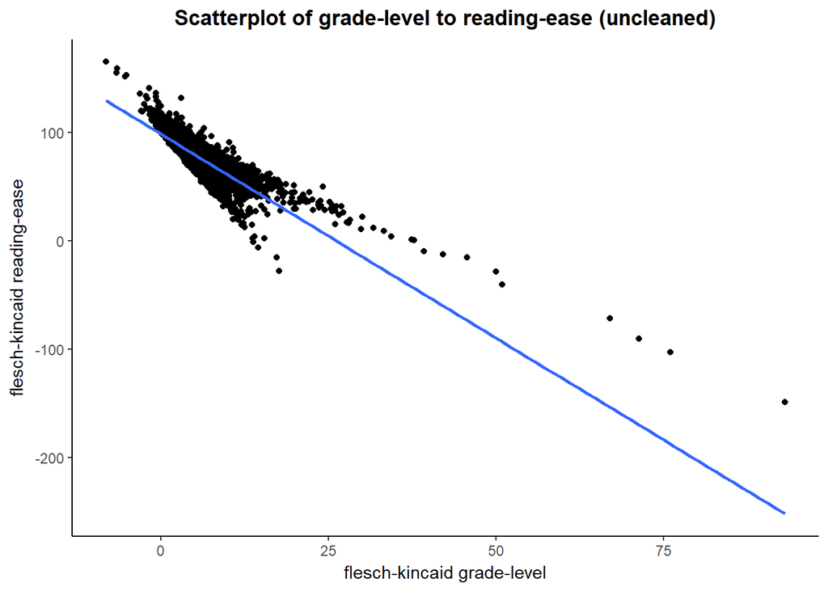

```r
ggplot(reviews_phoenix, aes(x = FK_grade_level, y = FK_reading_ease)) +
  geom_point(position = "jitter") +
  theme_classic() +
  ggtitle("Scatterplot of grade-level to reading-ease (uncleaned)") +
  theme(plot.title = element_text(face = "bold", hjust = 0.5)) +
  xlab("flesch-kincaid grade-level") +
  ylab("flesch-kincaid reading-ease") +
  stat_smooth(method=lm, level=FALSE)
```

```r
reviews_phoenix %>% summarise(unclean_highest_fk_grade = max(FK_grade_level),
                              unclean_lowest_fk_grade = min(FK_grade_level),
                              unclean_highest_reading_difficulty = max(FK_reading_ease),
                              unclean_lowest_reading_difficulty = min(FK_reading_ease),
                              unclean_mean_grade_lvl = mean(FK_grade_level),
                              unclean_mean_reading_ease = mean(FK_reading_ease),
                              unclean_percentile_99 = quantile(FK_grade_level, .99))
```

```
## Source: local data table [1 x 7]
##
## # A tibble: 1 x 7
##   unclean_highest_~ unclean_lowest_f~ unclean_highest_r~ unclean_lowest_r~
##               <dbl>             <dbl>              <dbl>             <dbl>
## 1              93.1             -8.22               165.             -149.
## # ... with 3 more variables: unclean_mean_grade_lvl <dbl>,
## #   unclean_mean_reading_ease <dbl>, unclean_percentile_99 <dbl>
```

```r
reviews_phoenix %>% filter(FK_reading_ease < 30 | FK_reading_ease > 100) %>% summarise(n_not_in_bounds = n())
```

```
## Source: local data table [1 x 1]
##
## # A tibble: 1 x 1
##   n_not_in_bounds
##             <int>
## 1             550
```

```r
# "Dateien/reviews_after_fk.RData" wird benötigt
gc()

reviews_phoenix = filter(reviews_phoenix, FK_reading_ease > 30 & FK_reading_ease < 100)

reviews_phoenix = filter(reviews_phoenix, FK_grade_level < quantile(FK_grade_level, .99))

save(reviews_phoenix, file = "Dateien/reviews_after_fk_cleaned.RData")
```

Die folgende Graphik zeigt die korregierte Verteilung des grade-level gegen den reading-ease-Wert geplottet, durch die nun ein schönes lineares Modell gelegt werden kann um das sich die Werte gut verteilen. Sollten die Faktoren grade-level und reading-ease ausschlaggebend für die Klassifizierung sein, sollte das Modell nun nicht mehr von Ausreißern beeinflusst und die Leseschwierigkeit als potenzieller Prädiktor ins Modell aufgenommen werden können.

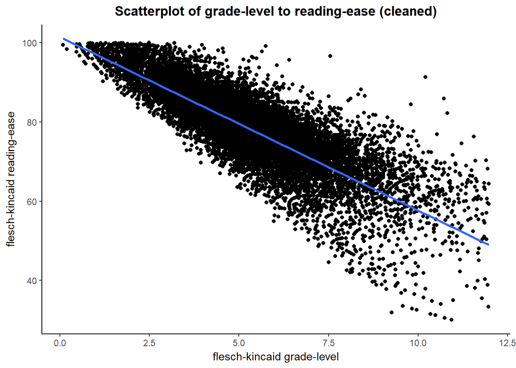

```r
ggplot(reviews_phoenix, aes(x = FK_grade_level, y = FK_reading_ease)) +
  geom_point(position = "jitter") +
  theme_classic() +
  ggtitle("Scatterplot of grade-level to reading-ease (cleaned)") +
  theme(plot.title = element_text(face = "bold", hjust = 0.5)) +
  xlab("flesch-kincaid grade-level") +
  ylab("flesch-kincaid reading-ease") +
  stat_smooth(method=lm, level=FALSE)
```

```r
reviews_phoenix %>% summarise(clean_highest_fk_grade = max(FK_grade_level),
                              clean_lowest_fk_grade = min(FK_grade_level),
                              clean_highest_reading_difficulty = min(FK_reading_ease),
                              clean_lowest_reading_difficulty = max(FK_reading_ease),
                              clean_mean_grade_lvl = mean(FK_grade_level),
                              clean_mean_reading_ease = mean(FK_reading_ease),
                              clean_percentile_99 = quantile(FK_grade_level, .99))
```

```
## Source: local data table [1 x 7]
##
## # A tibble: 1 x 7
##   clean_highest_fk~ clean_lowest_fk_~ clean_highest_rea~ clean_lowest_rea~
##               <dbl>             <dbl>              <dbl>             <dbl>
## 1              12.0            0.0915               30.0             100.0
## # ... with 3 more variables: clean_mean_grade_lvl <dbl>,
## #   clean_mean_reading_ease <dbl>, clean_percentile_99 <dbl>
```

## 4.2 Die Polarität der Bewertungen

Eine weitere Möglichkeit um Informationen aus dem Text zu gewinnen ist die Polarität des Reviews zu bestimmen. Die Polaritätsfunktion weißt einem Review, je nach Anzahl positiver und negativer Wörter, sowie deren Kontext mit Verstärkungs-, Schwächungs- und Umkehrwörter einen Polaritätswert zu, der Aussagen soll, wie positiv bzw. negativ ein Review behaftet ist. Je niedriger der Wert, desto negativer ist das Kommentar und umgekehrt.

### 4.2.1 Die adaptierte Form der `polarity`-Funktion von qdap

Eine von mir adaptierte Form der polarity-Funktion von qdap (`getAnywhere(qdap::polarity)`) erfüllt hier meine Ansprüche. Der Grund der Adaption war wieder die Effizienz der Funktion mit dem Hauptgrund der Arbeitsspeicherschonung und schnelleren Ausführung, ist aber auch wieder rigider als die Ursprungsfunktion.

Die Funktion selbst benötigt einige Hilfsfunktionen - alle Schritte sind wieder im folgenden Codeabschnitt kommentiert.

```r
###Eine Funktion, die die Polarität (stark negativ (hohe Minusahlen) - stark positiv (hohe Pluszahlen)) zurückgibt
# getAnywhere(polarity)- wenn Sie die Originalfunktion sehen wollen
modified_polarity <- function (data_frame, text.var, grouping.var = NULL, polarity.frame = qdapDictionaries::key.pol,
                               negators = qdapDictionaries::negation.words, amplifiers = qdapDictionaries::amplification.words,
                               deamplifiers = qdapDictionaries::deamplification.words, question.weight = 0, amplifier.weight = .8, n.before = 4, n.after = 2, rm.incomplete = FALSE, digits = 3, polkey = qdapDictionaries::key.pol) {

  ## Neues Datenset, was nur Textvariable beinhaltet
  DF <- data.frame(text.var, check.names = FALSE, stringsAsFactors = FALSE)


  ## Erstellt ein "Wörterbuch", in dem positive und negative Wörter eingesehen werden können, för mehr Informationen siehe Hilfsfunktion "polarity.frame"
  if (!is.environment(polarity.frame)) {
    if (!is.data.frame(polarity.frame)) {
      stop(paste("Please supply a dataframe or environment",
                 "(see `polarity_frame`) to polarity.frame"))
    }
    polarity.frame <- hash(polarity.frame)
  }


  ## Ein Wörterbuch, in dem Negatoren, Amplifikatoren und Deamplifikatoren einer Zahl zugeordnet werden - für nähere Information siehe alter_env-Funktion
  alter <- alter_env(negators, amplifiers, deamplifiers)

  ## nimmt die polarisierten Wörter und schaut, wo diese im Datenset vorkommen
  posneg <- polarity.frame[["x"]]
  words <- c(posneg, alter[["words"]])

  ## Sätze werden in einzelne Wörter zerlegt
  counts <- unlist(lapply(DF[, "text.var"], function(x) length(bag_o_words(x))))

  # markiert die Zielwörter für die spätere Funktion
  DF[, "text.var"] <- space_fill(text = strip(DF[, "text.var"]), terms = words[grep("\\s", words)], sep = "~~")


  ## zerlegt Sätze wieder in einzelne, wenn sie markierte Zielwörter enthalten
  TV <- lapply(lapply(DF[, "text.var"], bag_o_words), function(x) {
    gsub("~~", " ", x)
  })


  ## Gibt die Positiion der polarisierten Wörter zurück
  hits <- lapply(TV, function(x) which(x %in% posneg))

  ## Eine gestappelte Schleife, die mit Hilfe der polarity_helper-Funktion die einzelnen polarity-scores, positiven und negativen Wörter
  pols <- list()
  output <- list()
  polwords <- list()
  for (i in seq_along(hits)) {
    vlen <- ifelse(identical(hits[[i]], integer(0)), 1, length(hits[[i]]))
    pols[[i]] <- rep(0, vlen)
    output[[i]] <- rep(0, vlen)
    polwords[[i]] <- rep(NA, vlen)
    for(j in seq_along(hits[[i]])) {
      theoutputs <- polarity_helper(tv = TV[[i]], hit=hits[[i]][[j]],
                                    polenv = polkey, altenv = alter, count = counts[i],
                                    n.before = n.before, n.after = n.after, amp.weight = amplifier.weight)
      output[[i]][j] <- theoutputs[[1]] #der Polaritätswert inkl. Kontext
      pols[[i]][j] <- theoutputs[[2]] #die Verstärkungswörter
      polwords[[i]][j] <- theoutputs[[3]] # die Polaritätswörter
    }
  }


  ## Construct sentence data.frame
  scores <- sapply(output, sum)/counts #die Summe aller Polaritätswerte der einzelnen Sätze eines Kommentars dividiert durch die Anzahl der Wörter ist der finale Polaritätswert
  all <- mutate(data_frame, wordcount_after_prepro = counts, polarity = scores) #einfügen vom Wordcount und der Polarität in das Ursprungsdatenset

  ## Funktion, die alle targets, wo die Polarität des Satzes > 0 (positive Wörter) ist, zurückgeben
  pwords <- function(x, y) {
    out <- y[x > 0]
    if (identical(out, character(0)) | identical(out, logical(0))) { #ist die Polarität null, wird nichts zurückgegeben
      return("-")
    }
    out
  }
  ## Funktion, die alle targets, wo die Polarität des Satzes < 0 (negative Wörter) ist, zurückgeben
  nwords <- function(x, y) {
    out <- y[x < 0]
    if (identical(out, character(0)) | identical(out, logical(0))) { #ist die Polarität null, wird nichts zurückgegeben
      return("-")
    }
    out
  }

  ##function to count the positive and negative words of a comment and add it to the all



  ### Anzahl positiver Wörter zählen, damit Datenset nicht unnötig groß wird, da nur Anzahl, nicht aber die Wörter selbst gebraucht werden (und wenn keines vorkommt ("-") 0 speichern)

  for(i in 1:length(polwords)) {
    pos.word_count = list()
    if("-" %in% pwords(pols[[i]], polwords[[i]]) == T) { #ist der Polaritätswert leer ("-"), wird 0 anstatt eines - eingefügt
      all$pos.word_count[i] = 0}
    else {
      all$pos.word_count[i] = length(word_count(pwords(pols[[i]], polwords[[i]]))) #ansonsten die Anzahl aller positiven Wörter zählen
    }
    mutate(all, pos.words_count = pos.word_count) #den neuen Wert zum Ursprungsdatenset hinzufügen
  }

  ### Anzahl negativer Wörter zählen, damit Datenset nicht unnötig groß wird, da nur Anzahl, nicht aber die Wörter selbst gebraucht werden (und wenn keines vorkommt ("-") 0 speichern)

  for(i in 1:length(polwords)) {
    neg.word_count = list()
    if("-" %in% nwords(pols[[i]], polwords[[i]]) == T) {
      all$neg.word_count[i] = 0}
    else {
      all$neg.word_count[i] = length(word_count(nwords(pols[[i]], polwords[[i]])))
    }
    mutate(all, neg.words_count = neg.word_count)
  }

  #zurückgeben des Ursprungsdatensets mit neuen Werten (Polarität, Anzahl negativer & positiver Wörter und die Anzahl aller Wörter nach dem preprocessing des Textes)
  return(all)

}

gc()
```

```
##            used  (Mb) gc trigger   (Mb)  max used   (Mb)
## Ncells  9990557 533.6   25102783 1340.7  25102783 1340.7
## Vcells 51113937 390.0  206835922 1578.1 708139294 5402.7
```

### 4.2.2 Die Hilfsfunktion `alter_env`

```r
### Hilfsfunktion für die modifizierte polarity-Funktion (kopiert aus "https://github.com/trinker/qdap/blob/master/inst/polarity/polarity.R" Codezeile 4 - 75)
#erstellt ein "Wörterbuch", in dem den einzelnen Verstärkungswörtern (Zahl 2), Schwächungswörtern (Zahl 3) und Negatoren (Zahl 1) eine Zahl zugewiesen wird, die aussagt, ob diese das vorhergehende/nachfolgende Wort verstärken ('besser als' perfekt), schwächen ('fast' ausgezeichnet) oder die Bedeutung umdrehen (z.B. 'nicht' so toll)
alter_env <- function(negators, amplifiers, deamplifiers) {
  n <- rep(1, length(negators))
  a <- rep(2, length(amplifiers))
  d <- rep(3, length(deamplifiers))
  #die Funktion hash erstellt das "Wörterbuch" mit den zugeordneten Zahlen
  hash(data.frame(words=c(negators, amplifiers, deamplifiers), value=c(n, a, d)))
}

polarity_frame <- function(positives, negatives, pos.weights = 1, neg.weights = -1, envir = TRUE) {
  plen <- length(positives)
  nlen <- length(negatives)
  if (length(pos.weights) == 1) {
    pos.weights <- rep(pos.weights, plen) #erstellt einen Vektor, um im folgenden Schritt allen positiven Wörtern die Zahl 1 zuzuweisen
  }
  if (length(neg.weights) == 1) {
    neg.weights <- rep(neg.weights, nlen) #erstellt einen Vektor, um im folgenden Schritt allen negativen Wörtern die Zahl -1 zuzuweisen
  }
  dat <- data.frame(words = c(positives, negatives), polarity = c(pos.weights, neg.weights)) #weißt den Wörtern die Zahlen zu
  if (envir) {
    hash(dat)
  } else {
    dat
  }
}
```

### 4.2.3 Die Hilfsfunktion `polarity_helper`

```r
# eine Hilfsfunktion, die die Polarität der einzelnen Wörter berechnen soll
polarity_helper <- function(tv, hit, polenv, altenv, count, amp.weight, n.before, n.after) {
  #gibt es keinen Hit, wird eine leere Liste zurückgegeben
  if (identical(hit, integer(0))) {
    return(list(0, 0))
  }

  ## markiert die polarisierten Wörter
  target <- ifelse((hit - n.before) < 1, hit, n.before + 1)

  ## nimmt die in n.before und n.after definierten Wörter und bestimmt Unter- und Obergrenzen um das Target und wählt den Bereich aus
  lower <- ifelse((hit - n.before) < 1, 1, hit - n.before)
  upper <- ifelse((hit + n.after) > count, count, hit + n.after)
  inds <- lower:upper
  words <- tv[inds]

  ## im Wörterbuch werden die polarisierten Wörter nachgeschlagen
  targ <- words[target]
  p <- hash_look(targ, polenv)

  ## Berechnet, wie die Kontextwörter (Amp, Deamp, und Negatoren) die Polarität des Satzes verändern
  context <- hash_look(words[-target], altenv)
  if (!is.null(context)) { #ist der Kontext nicht 0, wird der Kontext mit eingerechnet
    context <- unlist(lapply(split(context, context), length))
    ident <- function(x, y) if (!x %in% names(y)) 0 else y[names(y) == x]
    n <- ident("1", context)
    a <- ident("2", context)
    d <- ident("3", context)
    D <- (d + ifelse(n %% 2 != 0, 1, 0) * a) * ((-1) * amp.weight)
    A <- (ifelse(n %% 2 == 0, 1, 0) * a * amp.weight)
  } else { #kein Kontext -> keine Kontextveränderung
    D <- A <- n <- 0
  }

  ## gibt den neuen Polaritätswert mit inkludierten Kontext (x), die Verstärkungswörter (y), sowie die polarisierten Wörter (neg + pos; z) zurück
  list(x = (1 + (D + A)) * (p * (-1)^(2 + n)), y = p, z = targ)
}
```

## 4.2.4 Die Durchführung der `modified_polarity`-Funktion

Der folgende Codeabschnitt führt die Funktion, je nach Anzahl der Kerne, entweder wieder parallel oder normal aus und erweitert somit das Ursprungsdatenset um folgenden Kennwerte: - Den Polaritätswert (wie oben beschrieben) - Die Anzahl positiver Wörter - Die Anzahl negativer Wörter

```r
# "Dateien/reviews_after_fk_cleaned.RData" wird benötigt

#durchführen der Polaritätsfunktion an den Review-Daten (wenn möglich parallelisiert)
cores = detectCores()/2
if(cores >= 2) {
  cl = makeCluster(cores)
  registerDoParallel(cl)
  reviews_phoenix <- suppressWarnings(
                    modified_polarity(text.var = reviews_phoenix$text, data_frame = reviews_phoenix))
  reviews_phoenix = as.data.table(reviews_phoenix)
  save(reviews_phoenix, file = "Dateien/reviews_after_polarity.RData")
  stopCluster(cl)
} else {
  reviews_phoenix <- suppressWarnings(
                    modified_polarity(text.var = reviews_phoenix$text, data_frame = reviews_phoenix))
  reviews_phoenix = as.data.table(reviews_phoenix)
  save(reviews_phoenix, file = "Dateien/reviews_after_polarity.RData")
}


gc()
```

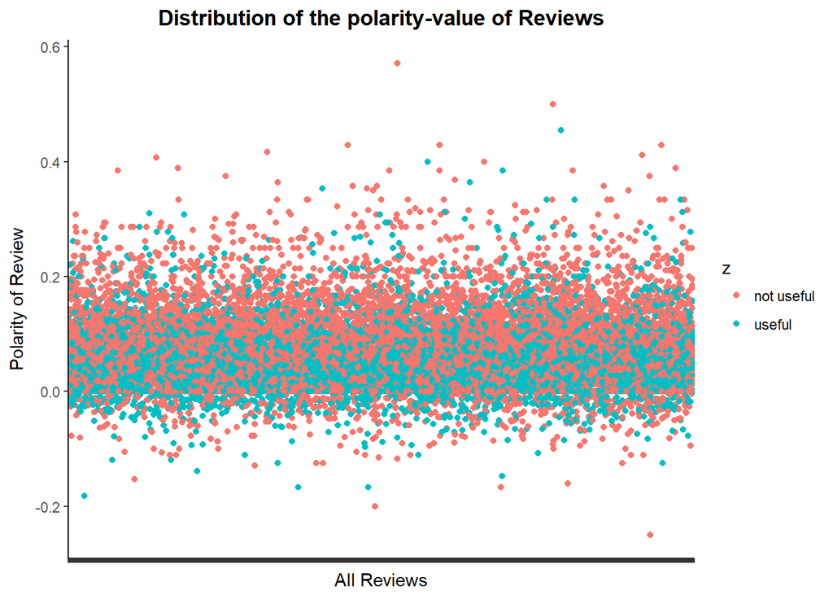

```r
z = as.factor(ifelse(reviews_phoenix$useful > 0, 2, 1))
levels(z) = c("not useful", "useful")

ggplot(reviews_phoenix, aes(x = review_id, y = polarity, color = z)) +
  geom_point(stat = "identity", position = "jitter") +
  theme_classic() +
  theme(axis.text.x=element_blank()) +
  ggtitle("Distribution of the polarity-value of Reviews") +
  theme(plot.title = element_text(face = "bold", hjust = 0.5)) +
  xlab("All Reviews") +
  ylab("Polarity of Review")
```